# Flexible Damage Functions

Author

James Rising, Sebastian Cadavid Sanchez, Climate Impact Lab

Published

April 30, 2026

## 0.1 Energy: Non Electricity Country

Flexible damage function parameters at the Country level.

**Outcome units:** `kWh_per_capita` — kWh per capita for non electricity, rebased to 2005 baseline; pre-aggregated to country in projection system

$$D_{it} = (\alpha_i T_t + \beta_i T_t^2) \cdot Y_{it}^{\gamma}$$

where $\gamma$ is the income elasticity (fitted globally), $\alpha_i$ is the linear coefficient, and $\beta_i$ is the quadratic coefficient.

# 1 Global Estimation

## 1.1 Income Elasticity Estimation

The income elasticity $\gamma$ is estimated using a fixed-effects regression:

$$y_{it} = \gamma \cdot \log(Y_{it}) + \mu_{g(i,T)} + \nu_t + \varepsilon_{it}$$

where $\mu_{g(i,T)}$ are region-by-temperature-bin fixed effects and $\nu_t$ are year fixed effects.

Table 1: Income Elasticity (Gamma) Estimation Results

| Statistic | Value |
| --- | --- |
| Income elasticity ($\gamma$) | -0.2307 |
| Standard error | 2.02e-02 |
| 95% CI | [-0.2703, -0.1910] |
| R-squared | 0.9098 |
| Observations | 3,519,180 |
| Regions | 245 |
| Gamma quantiles | 19 |

# 2 Parameter Distributions

## 2.1 8-Panel Summary

Row 1: gamma, alpha, beta, rsqr1. Row 2: rho, zeta, eta, rsqr2.

```
Using median gamma: -0.230683, 245 rows (of 4,655 total)
```

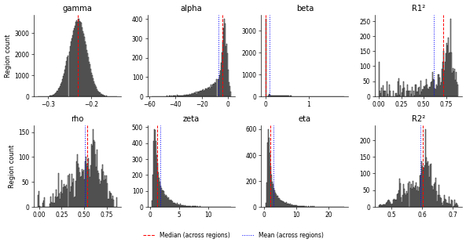

Figure 1: Distribution of Regional Parameters

## 2.2 Projection Equation and Parameter Definitions

The estimated parameters are used to project damages via Monte Carlo sampling:

$$D_{it}^k = (\hat{\alpha}_{ik} T_t + \hat{\beta}_{ik} T_t^2) Y_{it}^{\hat{\gamma}_k} + \hat{\theta}_{ik} T_t Y_{it}^{\hat{\gamma}_k} + \hat{\phi}_{it}^k$$

where $k$ indexes the Monte Carlo draw. The parameters in each row of the output CSV control distinct components of this equation:

- **gamma**: income elasticity $\hat{\gamma}_k$, one of 19 quantile values drawn from $N(\hat{\gamma}, SE(\hat{\gamma}))$
- **alpha, beta**: linear and quadratic temperature coefficients; $\hat{\alpha}_{ik}$ and $\hat{\beta}_{ik}$ are drawn from the joint normal defined by the VCV below
- **sigma11, sigma12, sigma22**: variance-covariance matrix of $(\alpha, \beta)$, used for joint uncertainty sampling
- **rho**: correlation between regional and global polynomial residuals $\rho_i$, used to maintain spatial covariance across regions in Monte Carlo draws
- **zeta**: temperature-dependent error scale $\zeta_{ik}$; the run-specific error term $\hat{\theta}_{ik}$ is drawn from $N(0, \zeta_{ik})$
- **eta**: residual noise standard deviation $\eta_{ik}$; the annual noise $\hat{\phi}_{it}^k$ is drawn from $N(0, \eta_{ik})$
- **rsqr1, rsqr2**: polynomial fit quality and error model fit, respectively

## 2.3 Summary Statistics

Table 2: Regional Parameter Summary

| Parameter | Mean | Median | Std | Min | Max | N |
| --- | --- | --- | --- | --- | --- | --- |
| alpha | -7.156 | -4.215 | 7.514 | -41.58 | 1.56 | 245 |
| beta | 0.09593 | 0 | 0.2278 | 0 | 1.422 | 245 |
| rho | 0.507 | 0.537 | 0.1748 | -0.01374 | 0.862 | 245 |
| zeta | 1.709 | 1.212 | 1.348 | 0.3867 | 9.681 | 245 |
| eta | 2.86 | 1.963 | 2.379 | 0.6865 | 17.28 | 245 |
| rsqr1 | 0.6105 | 0.7156 | 0.2382 | 4.081e-05 | 0.8822 | 245 |
| rsqr2 | 0.595 | 0.6034 | 0.04781 | 0.4627 | 0.7115 | 245 |

# 3 Spaghetti Curves

Regional damage function curves showing D(T) = αT + βT² for sampled regions.

[interactive chart not shown]

Figure 2: Regional Damage Functions

# 4 Zero Crossings

The zero crossing (extremum) of the parabola occurs at $T^* = -\alpha / (2\beta)$.

Table 3: Zero Crossing Statistics

| Category | Count | Percentage |
| --- | --- | --- |
| β = 0 (no crossing) | 184 | 75.1% |
| T > 20°C (beyond graph) | 38 | 15.5% |
| T < 0°C (negative crossing) | 0 | 0.0% |
| Valid crossings (0-20°C) | 23 | 9.4% |

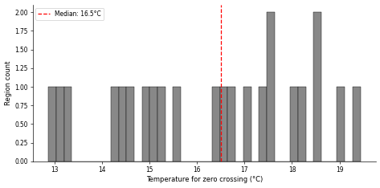

Figure 3: Distribution of Zero Crossing Temperatures

# 5 Slope Analysis

Maximum slope between 0 and 10°C: $\frac{dM}{dT} = \alpha + 2\beta T$

The maximum occurs at either T=0 or T=10 (endpoints of interval).

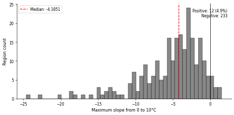

Figure 4: Distribution of Maximum Slopes (0-10°C)

*Convexity analysis omitted (beta constraint active).*

# 6 R-squared Analysis

## 6.1 Polynomial Fit Quality (rsqr1)

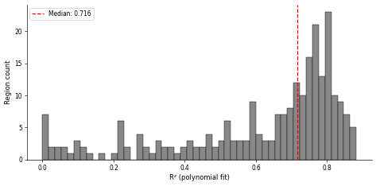

Figure 5: Regional Fit Quality (R-squared)

## 6.2 Error Model R-squared (rsqr2) Quantiles

Table 4: rsqr2 Quantiles

| 0% (Min) | 25% | 50% (Median) | 75% | 100% (Max) |
| --- | --- | --- | --- | --- |
| 0.4627 | 0.5626 | 0.6034 | 0.6248 | 0.7115 |

# 7 Modelled Variance

Modelled variance statistic: $1 - \frac{\sum_i \eta_i^2}{\sum_i D_i^2}$

Table 5: Modelled Variance Statistics

| Statistic | Value |
| --- | --- |
| Modelled variance | 0.9839 |
| Sum(η²) | 3385.0056 |
| Sum(D²) at T=3.0°C | 209950.8741 |
| N regions | 245 |

# 8 Best- and Worst-Fitting Regions

Table 6: Best- and worst-fitting regions

| Region | α | β | η | R² |
| --- | --- | --- | --- | --- |
| CHN | -11.1 | 0.234 | 2.56 | 0.867 |
| CAN | -30.5 | 1.01 | 7.04 | 0.864 |
| RUS | -25.5 | 0.526 | 6.46 | 0.863 |
| SHN | -2.4 | 0.0113 | 1.49 | 0.536 |
| MNG | -20.1 | 0.0805 | 9.33 | 0.6 |
| NFK | -3.27 | 0.0904 | 1.53 | 0.605 |

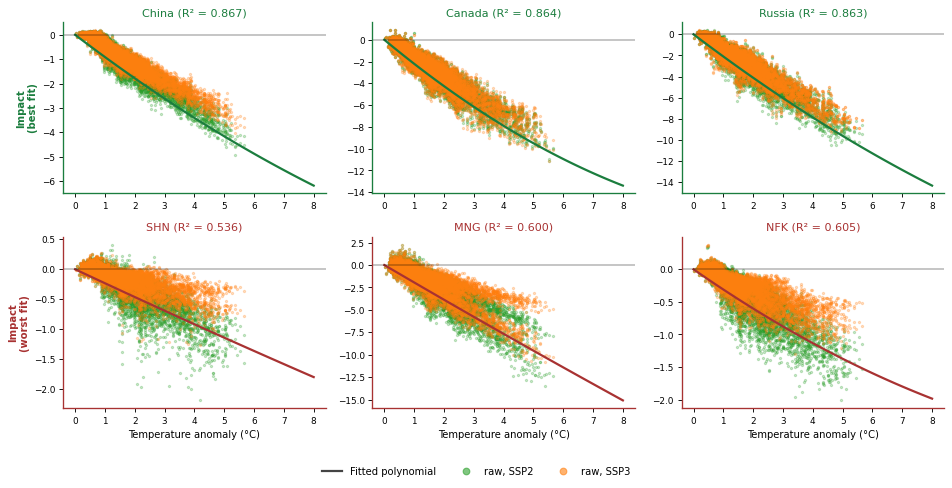

# 9 Regional Parameter Maps

Maps of key parameters at the **country** level. Red = negative (damage increases with T), Blue = positive.

## 9.1 Alpha (Linear Coefficient)

Alpha ($\alpha$) represents the linear sensitivity to temperature. Regions with negative alpha experience damage that increases with the first degree of warming.

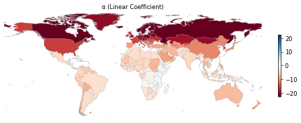

Figure 7: α (linear coefficient)

## 9.2 Beta (Quadratic Coefficient)

Beta ($\beta$) represents the curvature of the damage function.

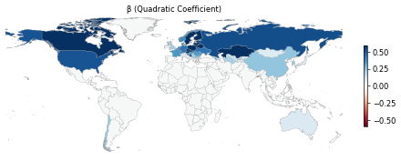

Figure 8: β (quadratic coefficient)

## 9.3 R-squared (Fit Quality)

$R^2$ measures the polynomial fit quality. Higher values indicate that the quadratic form captures more of the variance in the data.

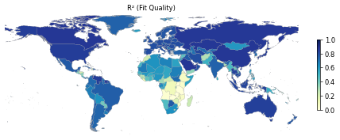

Figure 9: R² (stage 1 fit quality)

# 10 F2: Flex vs Raw Comparison

Comparison of flexible damage function predictions against raw simulation means.

For each scenario (RCP × SSP × Model), we compute at the final year:

- **Flex predicted**: $(\alpha \cdot T + \beta \cdot T^2) \cdot Y^\gamma$
- **Raw actual**: The outcome variable (y) from the source data

**Year 2099**: 65,780 rows

**rcp45**

**SSP2**

**high**

**Correlation:** 0.6514 | **RMSE:** 1.863795 | **Sign agreement:** 18.8%

[interactive chart not shown]

Top 5 best predicted Top 5 worst predicted

Year 2099 · T<sub>mean</sub> across these regions: 1.96°C

| Region | Raw | Flex | Residual |
| --- | --- | --- | --- |
| RWA | 0.378 | 0.251 | -0.127 |
| ERI | 0.324 | 0.071 | -0.253 |
| BDI | 0.546 | 0.264 | -0.282 |
| PCN | 0.169 | -0.124 | -0.294 |
| MDG | 0.514 | 0.173 | -0.34 |
| QAT | 2.87 | -2.14 | -5 |
| KWT | 2.57 | -1.88 | -4.45 |
| ARE | 2.43 | -1.67 | -4.11 |
| BHR | 2.16 | -1.93 | -4.08 |
| FIN | -1.11 | -4.51 | -3.4 |

**low**

**Correlation:** 0.5539 | **RMSE:** 1.805742 | **Sign agreement:** 18.4%

[interactive chart not shown]

Top 5 best predicted Top 5 worst predicted

Year 2099 · T<sub>mean</sub> across these regions: 1.96°C

| Region | Raw | Flex | Residual |
| --- | --- | --- | --- |
| ETH | 0.0351 | 0.152 | 0.117 |
| STP | 0.177 | 0.0431 | -0.133 |
| MWI | 0.308 | 0.167 | -0.141 |
| MDG | 0.0732 | 0.24 | 0.167 |
| TZA | 0.194 | 0.0228 | -0.171 |
| QAT | 2.87 | -2.14 | -5 |
| KWT | 2.14 | -2.08 | -4.23 |
| SJM | -2.28 | -6.44 | -4.16 |
| BHR | 2.24 | -1.89 | -4.13 |
| ARE | 2.43 | -1.67 | -4.11 |

**SSP3**

**high**

**Correlation:** 0.5149 | **RMSE:** 1.806873 | **Sign agreement:** 18.8%

[interactive chart not shown]

Top 5 best predicted Top 5 worst predicted

Year 2099 · T<sub>mean</sub> across these regions: 1.96°C

| Region | Raw | Flex | Residual |
| --- | --- | --- | --- |
| MWI | 0.18 | 0.182 | 0.00211 |
| KEN | 0.127 | 0.108 | -0.0194 |
| ERI | 0.154 | 0.105 | -0.0491 |
| ETH | 0.0356 | 0.151 | 0.115 |
| ZWE | 0.114 | 0.256 | 0.143 |
| SJM | -1.68 | -6.91 | -5.24 |
| QAT | 2.66 | -2.25 | -4.91 |
| KWT | 2.14 | -2.11 | -4.25 |
| ARE | 1.98 | -1.9 | -3.88 |
| BHR | 1.67 | -2.19 | -3.86 |

**low**

**Correlation:** 0.4064 | **RMSE:** 1.841629 | **Sign agreement:** 19.6%

[interactive chart not shown]

Top 5 best predicted Top 5 worst predicted

Year 2099 · T<sub>mean</sub> across these regions: 1.96°C

| Region | Raw | Flex | Residual |
| --- | --- | --- | --- |
| STP | 0.0486 | 0.0579 | 0.00927 |
| ERI | 0.16 | 0.0993 | -0.0604 |
| KEN | 0.0729 | 0.136 | 0.0635 |
| MWI | 0.16 | 0.241 | 0.0809 |
| SWZ | 0.0447 | -0.0589 | -0.104 |
| SJM | -0.907 | -7.54 | -6.63 |
| QAT | 2.66 | -2.25 | -4.91 |
| MNG | 0.11 | -4.61 | -4.72 |
| KWT | 1.99 | -2.16 | -4.15 |
| BHR | 1.96 | -2.03 | -3.99 |

**rcp85**

**SSP2**

**high**

**Correlation:** 0.5825 | **RMSE:** 4.359976 | **Sign agreement:** 14.7%

[interactive chart not shown]

Top 5 best predicted Top 5 worst predicted

Year 2099 · T<sub>mean</sub> across these regions: 4.20°C

| Region | Raw | Flex | Residual |
| --- | --- | --- | --- |
| ERI | 0.85 | 0.152 | -0.697 |
| RWA | 1.34 | 0.54 | -0.8 |
| PCN | 0.629 | -0.267 | -0.897 |
| MDG | 1.35 | 0.372 | -0.98 |
| BDI | 1.72 | 0.567 | -1.16 |
| QAT | 7.33 | -4.59 | -11.9 |
| KWT | 6.83 | -4.04 | -10.9 |
| ARE | 6.11 | -3.59 | -9.71 |
| BHR | 5.53 | -4.14 | -9.67 |
| SAU | 5.12 | -2.79 | -7.91 |

**low**

**Correlation:** 0.4462 | **RMSE:** 4.136074 | **Sign agreement:** 14.7%

[interactive chart not shown]

Top 5 best predicted Top 5 worst predicted

Year 2099 · T<sub>mean</sub> across these regions: 4.20°C

| Region | Raw | Flex | Residual |
| --- | --- | --- | --- |
| ETH | 0.139 | 0.327 | 0.188 |
| ZWE | 0.325 | 0.611 | 0.285 |
| MDG | 0.218 | 0.516 | 0.297 |
| STP | 0.503 | 0.0925 | -0.411 |
| TZA | 0.488 | 0.0491 | -0.439 |
| QAT | 7.33 | -4.59 | -11.9 |
| KWT | 5.69 | -4.48 | -10.2 |
| BHR | 5.76 | -4.06 | -9.81 |
| ARE | 6.11 | -3.59 | -9.71 |
| SJM | -3.73 | -12.7 | -8.96 |

**SSP3**

**high**

**Correlation:** 0.4056 | **RMSE:** 4.092567 | **Sign agreement:** 13.9%

[interactive chart not shown]

Top 5 best predicted Top 5 worst predicted

Year 2099 · T<sub>mean</sub> across these regions: 4.20°C

| Region | Raw | Flex | Residual |
| --- | --- | --- | --- |
| ETH | 0.192 | 0.325 | 0.133 |
| ZWE | 0.413 | 0.551 | 0.137 |
| MWI | 0.562 | 0.391 | -0.171 |
| KEN | 0.435 | 0.231 | -0.204 |
| MDG | 0.27 | 0.501 | 0.231 |
| QAT | 6.92 | -4.84 | -11.8 |
| SJM | -2.74 | -13.6 | -10.9 |
| KWT | 5.8 | -4.52 | -10.3 |
| ARE | 5.07 | -4.09 | -9.16 |
| BHR | 4.39 | -4.7 | -9.09 |

**low**

**Correlation:** 0.2923 | **RMSE:** 4.131832 | **Sign agreement:** 14.3%

[interactive chart not shown]

Top 5 best predicted Top 5 worst predicted

Year 2099 · T<sub>mean</sub> across these regions: 4.20°C

| Region | Raw | Flex | Residual |
| --- | --- | --- | --- |
| MWI | 0.526 | 0.518 | -0.0071 |
| KEN | 0.277 | 0.293 | 0.0158 |
| STP | 0.225 | 0.124 | -0.101 |
| ERI | 0.476 | 0.213 | -0.263 |
| SWZ | 0.247 | -0.126 | -0.373 |
| SJM | -1.48 | -14.9 | -13.4 |
| QAT | 6.92 | -4.84 | -11.8 |
| MNG | 0.25 | -9.81 | -10.1 |
| KWT | 5.37 | -4.65 | -10 |
| BHR | 5.15 | -4.35 | -9.5 |

## 10.1 Scenario Summary

| RCP | SSP | Model | N | Corr | RMSE | Sign% |
| --- | --- | --- | --- | --- | --- | --- |
| rcp45 | SSP2 | high | 245 | 0.6514 | 1.8638 | 18.8% |
| rcp45 | SSP2 | low | 245 | 0.5539 | 1.80574 | 18.4% |
| rcp45 | SSP3 | high | 245 | 0.5149 | 1.80687 | 18.8% |
| rcp45 | SSP3 | low | 245 | 0.4064 | 1.84163 | 19.6% |
| rcp85 | SSP2 | high | 245 | 0.5825 | 4.35998 | 14.7% |
| rcp85 | SSP2 | low | 245 | 0.4462 | 4.13607 | 14.7% |
| rcp85 | SSP3 | high | 245 | 0.4056 | 4.09257 | 13.9% |
| rcp85 | SSP3 | low | 245 | 0.2923 | 4.13183 | 14.3% |

# 11 Data Reference

## 11.1 File Locations

| Item | Path |
| --- | --- |
| Regional CSV | `/project/cil/gcp/flex_damage_funcs/parameters/energy__non_electricity_country__regional_parameters.csv` |
| Global JSON | `/project/cil/gcp/flex_damage_funcs/parameters/energy__non_electricity_country__global_results.json` |
| Metadata JSON | `/project/cil/gcp/flex_damage_funcs/parameters/energy__non_electricity_country__metadata.json` |

## 11.2 Column Definitions

| Column | Description |
| --- | --- |
| `region` | Region identifier (hierarchical code, first 3 chars = country ISO3) |
| `gamma` | Income elasticity quantile value |
| `alpha` | Linear temperature coefficient |
| `beta` | Quadratic temperature coefficient |
| `sigma11` | Var(alpha) |
| `sigma12` | Cov(alpha, beta) |
| `sigma22` | Var(beta) |
| `rho` | Correlation with global residual process |
| `zeta` | Temperature-dependent heteroskedasticity |
| `eta` | Residual standard deviation |
| `rsqr1` | R-squared of polynomial fit |
| `rsqr2` | R-squared of error model |

*Report generated with FlexDamage v1.0.0*